# Beyond the Finish Line: A Glance at Formula 1 and Ferrari

Eric L. Rehana H. Fatima T.

05-06-2025

# Introduction

##### F1, or Formula 1 was established in 1947. It is an international racing sport with open cockpit single seater cars consisting of over 20 races per season with 10 teams–also known as constructors– competing with two drivers each. Each season two championships are on the line, the constructors championship and the drivers championship. Points for these championships are earned by individual drivers by ranking well in Grand Prix races, and teams points are determined by consolidating the points individually earned by the drivers.

## What Were We Looking For

##### Formula 1 is an ever evolving sport that’s been around for decades. Due to this we were curious to see if overall performance has changed in the sport over time. Some of the things we sought out to analyze include:

1. How did qualifying times and lap times change over time?
2. Which teams had the most wins?
3. Does high performance in qualifying translate to high performance during the race?
4. Is there a correlation between qualifying rank and race finish position?
5. How did Ferrari’s performance look over time?

# Packages Used

```r
library(dplyr)
library(ggplot2)
library(tidyverse)
```

# Our Dataset

##### [Our Data](https://www.kaggle.com/datasets/rohanrao/formula-1-world-championship-1950-2020)

##### Our dataset came in the form of a database with multiple dataframes. It includes information such as information on all the drivers and teams that have competed in Formula 1, lap times by individual race, results for contstructor and driver championships, qualifying and srpint race results, grand prix results, and many more. The dataframes relevant to this project are the constructor IDs (to be used for filtering for the relevant contructors), constructor standings, qualifying, lap times, and results (displayed below). The information in our database spans from 1950 to 2024.

##### Constructor IDs:

```
## Rows: 212
## Columns: 5
## $ constructorId  <int> 1, 2, 3, 4, 5, 6, 7, 8, 9, 10, 11, 12, 13, 14, 15, 16, …
## $ constructorRef <chr> "mclaren", "bmw_sauber", "williams", "renault", "toro_r…
## $ name           <chr> "McLaren", "BMW Sauber", "Williams", "Renault", "Toro R…
## $ nationality    <chr> "British", "German", "British", "French", "Italian", "I…
## $ url            <chr> "http://en.wikipedia.org/wiki/McLaren", "http://en.wiki…
```

#### Constructor Standings:

```
## Rows: 13,391
## Columns: 7
## $ constructorStandingsId <int> 1, 2, 3, 4, 5, 6, 7, 8, 9, 10, 11, 12, 13, 14, …
## $ raceId                 <int> 18, 18, 18, 18, 18, 18, 19, 19, 19, 19, 19, 19,…
## $ constructorId          <int> 1, 2, 3, 4, 5, 6, 1, 2, 3, 4, 5, 6, 7, 9, 11, 1…
## $ points                 <dbl> 14, 8, 9, 5, 2, 1, 24, 19, 9, 6, 2, 11, 5, 2, 0…
## $ position               <int> 1, 3, 2, 4, 5, 6, 1, 2, 4, 5, 8, 3, 6, 7, 9, 10…
## $ positionText           <chr> "1", "3", "2", "4", "5", "6", "1", "2", "4", "5…
## $ wins                   <int> 1, 0, 0, 0, 0, 0, 1, 0, 0, 0, 0, 1, 0, 0, 0, 0,…
```

#### Qualifying Results:

```
## Rows: 10,494
## Columns: 9
## $ qualifyId     <int> 1, 2, 3, 4, 5, 6, 7, 8, 9, 10, 11, 12, 13, 14, 15, 16, 1…
## $ raceId        <int> 18, 18, 18, 18, 18, 18, 18, 18, 18, 18, 18, 18, 18, 18, …
## $ driverId      <int> 1, 9, 5, 13, 2, 15, 3, 14, 10, 20, 22, 4, 18, 6, 17, 8, …
## $ constructorId <int> 1, 2, 1, 6, 2, 7, 3, 9, 7, 5, 11, 4, 11, 3, 9, 6, 10, 5,…
## $ number        <int> 22, 4, 23, 2, 3, 11, 7, 9, 12, 15, 17, 5, 16, 8, 10, 1, …
## $ position      <int> 1, 2, 3, 4, 5, 6, 7, 8, 9, 10, 11, 12, 13, 14, 15, 16, 1…
## $ q1            <chr> "1:26.572", "1:26.103", "1:25.664", "1:25.994", "1:25.96…
## $ q2            <chr> "1:25.187", "1:25.315", "1:25.452", "1:25.691", "1:25.51…
## $ q3            <chr> "1:26.714", "1:26.869", "1:27.079", "1:27.178", "1:27.23…
```

#### Lap Times:

```
## Rows: 589,081
## Columns: 6
## $ raceId       <int> 841, 841, 841, 841, 841, 841, 841, 841, 841, 841, 841, 84…
## $ driverId     <int> 20, 20, 20, 20, 20, 20, 20, 20, 20, 20, 20, 20, 20, 20, 2…
## $ lap          <int> 1, 2, 3, 4, 5, 6, 7, 8, 9, 10, 11, 12, 13, 14, 15, 16, 17…
## $ position     <int> 1, 1, 1, 1, 1, 1, 1, 1, 1, 1, 1, 1, 1, 3, 4, 2, 1, 1, 1, …
## $ time         <chr> "1:38.109", "1:33.006", "1:32.713", "1:32.803", "1:32.342…
## $ milliseconds <int> 98109, 93006, 92713, 92803, 92342, 92605, 92502, 92537, 9…
```

#### Race Results:

```
## Rows: 26,759
## Columns: 18
## $ resultId        <int> 1, 2, 3, 4, 5, 6, 7, 8, 9, 10, 11, 12, 13, 14, 15, 16,…
## $ raceId          <int> 18, 18, 18, 18, 18, 18, 18, 18, 18, 18, 18, 18, 18, 18…
## $ driverId        <int> 1, 2, 3, 4, 5, 6, 7, 8, 9, 10, 11, 12, 13, 14, 15, 16,…
## $ constructorId   <int> 1, 2, 3, 4, 1, 3, 5, 6, 2, 7, 8, 4, 6, 9, 7, 10, 9, 11…
## $ number          <chr> "22", "3", "7", "5", "23", "8", "14", "1", "4", "12", …
## $ grid            <int> 1, 5, 7, 11, 3, 13, 17, 15, 2, 18, 19, 20, 4, 8, 6, 22…
## $ position        <chr> "1", "2", "3", "4", "5", "6", "7", "8", "\\N", "\\N", …
## $ positionText    <chr> "1", "2", "3", "4", "5", "6", "7", "8", "R", "R", "R",…
## $ positionOrder   <int> 1, 2, 3, 4, 5, 6, 7, 8, 9, 10, 11, 12, 13, 14, 15, 16,…
## $ points          <dbl> 10, 8, 6, 5, 4, 3, 2, 1, 0, 0, 0, 0, 0, 0, 0, 0, 0, 0,…
## $ laps            <int> 58, 58, 58, 58, 58, 57, 55, 53, 47, 43, 32, 30, 29, 25…
## $ time            <chr> "1:34:50.616", "+5.478", "+8.163", "+17.181", "+18.014…
## $ milliseconds    <chr> "5690616", "5696094", "5698779", "5707797", "5708630",…
## $ fastestLap      <chr> "39", "41", "41", "58", "43", "50", "54", "20", "15", …
## $ rank            <chr> "2", "3", "5", "7", "1", "14", "8", "4", "9", "13", "1…
## $ fastestLapTime  <chr> "1:27.452", "1:27.739", "1:28.090", "1:28.603", "1:27.…
## $ fastestLapSpeed <chr> "218.300", "217.586", "216.719", "215.464", "218.385",…
## $ statusId        <int> 1, 1, 1, 1, 1, 11, 5, 5, 4, 3, 7, 8, 5, 4, 10, 9, 4, 4…
```

# Prepping our Data

##### There was a lot of work to be done to prep our data and ensure it was useable for plotting. We mainly had to use joins to add year and constructor information to the dataframes that did not include that information. Additionally, we filtered for the constructors we would be analyzing. We also needed to create functions to convert any time data into only seconds to be able to plot time data.

### Our Functions

Used to convert all time data to seconds

```r
#convert "min:sec.ms" string to total seconds (as a number)
time_to_seconds <- function(time_str) {
  parts <- str_split_fixed(time_str, ":", 2)
  minutes <- as.numeric(parts[, 1])
  seconds_ms <- as.numeric(parts[, 2])
  return(minutes * 60 + seconds_ms)
}

#convert total seconds back to "min:sec.ms" format
seconds_to_time <- function(total_seconds) {
  minutes <- floor(total_seconds / 60)
  remaining_seconds <- total_seconds - (minutes * 60)
  return(sprintf("%d:%.3f", minutes, remaining_seconds))
}
```

### Our Joins

These were used to add year and constructor information to the dataframes we would be working with to allow us to analyze trends in performance over the course of the sport.

```r
#adding years to qualifying data
qualifying_by_year<-left_join(races, qualifying_average)
qualifying_by_year = left_join(qualifying_by_year, constructors, by = join_by(constructorId))

#results data by year
results_LapTimeSeconds <- results %>%
  mutate(fastestLapTime_seconds = sapply(fastestLapTime , time_to_seconds))

results_by_year<- left_join(races, results_LapTimeSeconds, by = join_by(raceId))
results_by_year = left_join(results_by_year, constructors, by = join_by(constructorId))

#constructor standings by year
constructor_standings_by_year<-left_join(races, constructor_standings)
```

# A Glance at F1

###### With over 100 teams having competed over the years, we decided to take a look at the 10 that raced in the 2024 season.

#### Fastest Lap Times by Season by Team*

##### Looking at this graph we can see that lap times significantly increased from 2006 to 2013, then experienced a severe decline. This tells us that cars were slower during that time period. In addition, this graph tells us that Alpine, Aston Martin, and Alpha Tauri did not start competing as constructors in Formula 1 until at least 2020.

*The graph only shows data from 2005 due to there not being data available before 2005 on lap times.

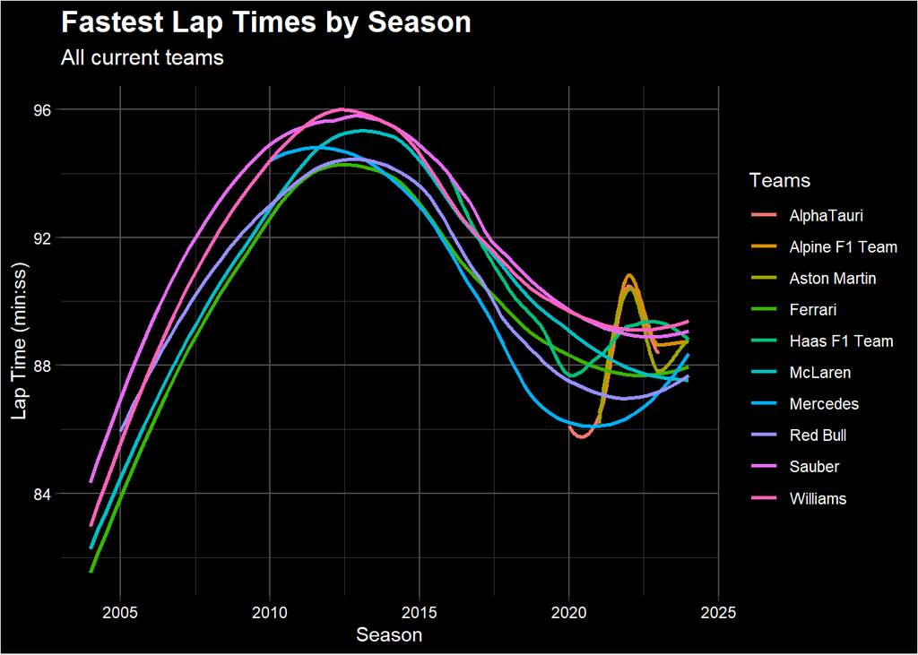

#### Average Qualifying Times by Season by Team

##### For this graph, the lower the qualifying time the better as it means the cars were faster. We see a similar trend in lap times with quaifying times increasing across the board from 2006 to 2013.

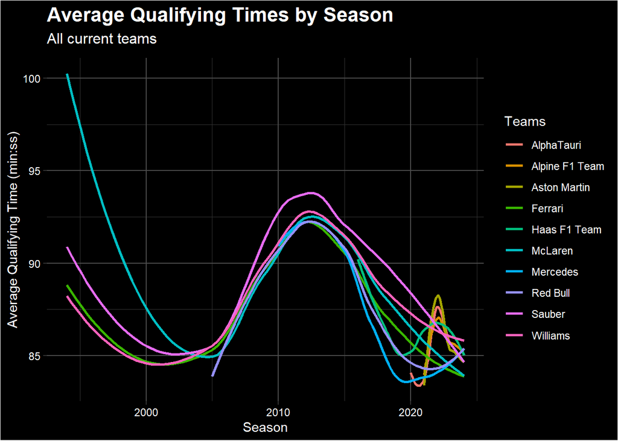

#### Number of Wins Per Season by Team*

##### This graph shows the number of times each current teams have won races over the years. We can see that among them McLaren and Ferrari were around and winning for the longest, while Mercedes and Red Bull have been earning more wins overall, but in recent years.

*Teams with no graph data have not had any wins.

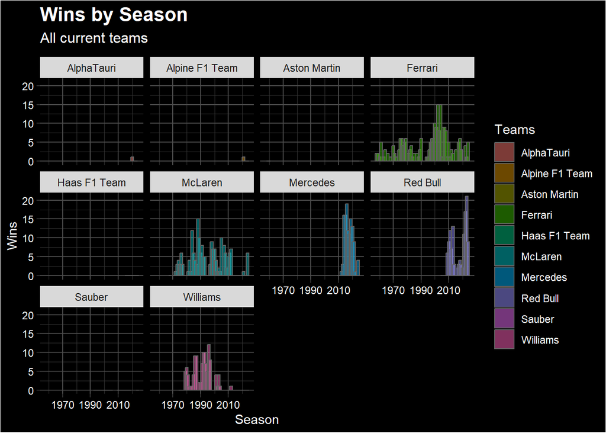

##### After taking a look at all the graphs above, we noticed that Ferrari has both been around since the conception of the sport and also been performing consistently well throughout its time competing in Formula 1. Due to these characteristics, we decided to do our focused analyses on the Ferrari team.

# Now Let’s Take a Look at Ferrari!

To process our data further and extract only the information relevant to Ferrari, we filtered by the ID associated with Ferrari and averaged our data by season/year to make our graphs easier to comprehend. Unfortunately, after processing, many of our visualizations only span as far back as 1994 or 2004 due to missing data. To ensure comprehensive analysis, we analyzed several variables in search of correlations regarding qualifying times and fastest lap times, qualifying positions and finishing positions. Beyond such, we visualized Ferrari’s rank over time, wins over time, and race runtime over time to determine an overall trend.

#### Ferrari Qualifying Times by Year

First, we have qualifying times since 1994. Here you can see a downward trend until 2006 where the trend reverses up until 2013 before returning to a downward trend.

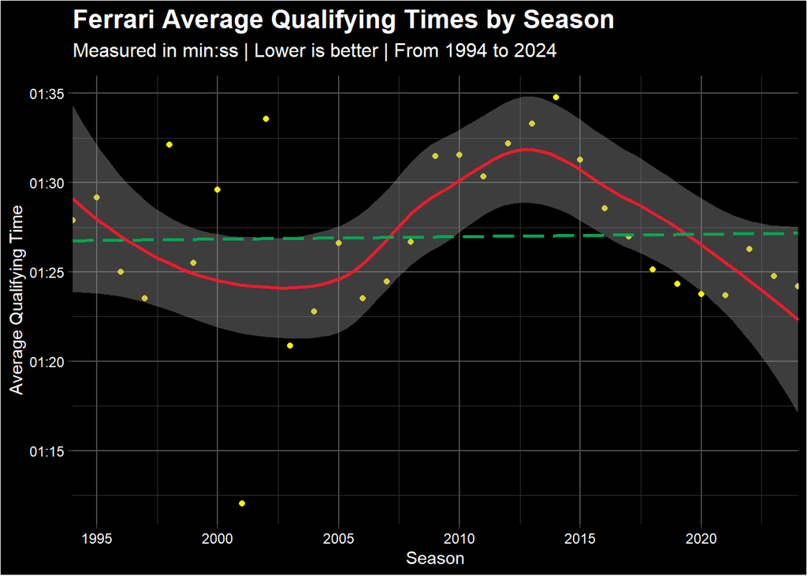

#### Ferrari’s Fastest Lap Times

Next, Fastest lap time, is referring to the average fastest lap time during a championship race, not qualifying. A similar story to our previous graph can be interpreted but this time we only have data from 2005 and beyond. From 2005 to 2013 there is an upward trend and after 2013 the trend reverses. This aligns with our previous graph and can conclude that qualifying times are correlated with fastest lap time.

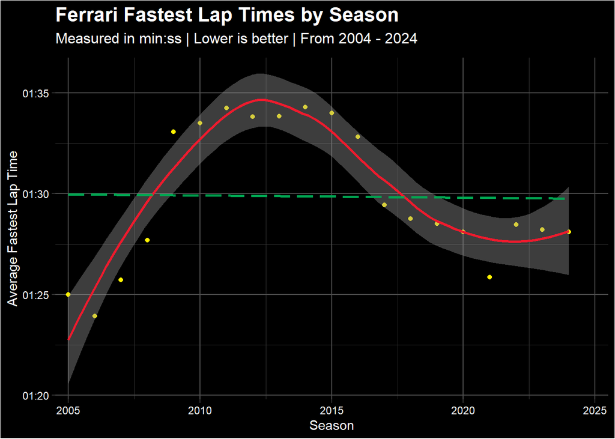

#### Ferrari’s Fastest Lap Speed

Below shows Ferrari’s average fastest lap speed during a championship race. This trend shows the inverse of the previous graphs but yet again tells the same story. In 2006 Ferrari’s speed decreased on average before increasing after 2013.

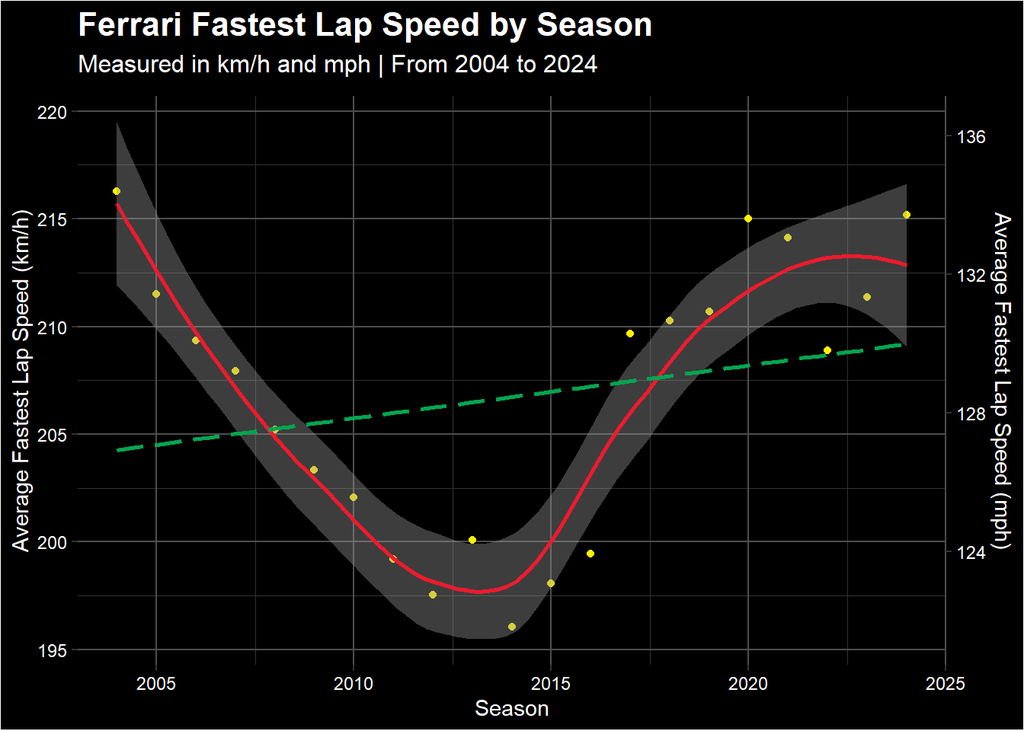

#### Ferrari’s Finish Positions

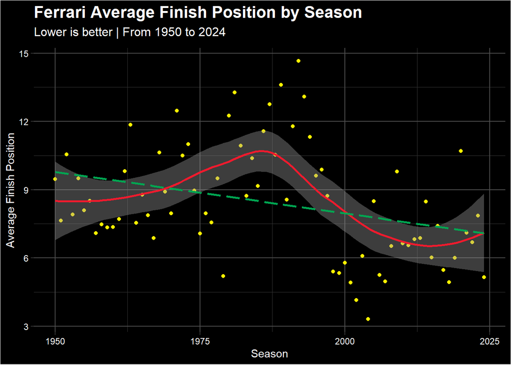

#### Ferrari’s Qualifying Positions VS Their Finish Positions

Because we intend to show a correlation between the average qualifying finish position and average championship finish position, we took the previous graph and scaled it to match our qualifying position graph which only spans from 1994 to 2024. See the next graph to compare.

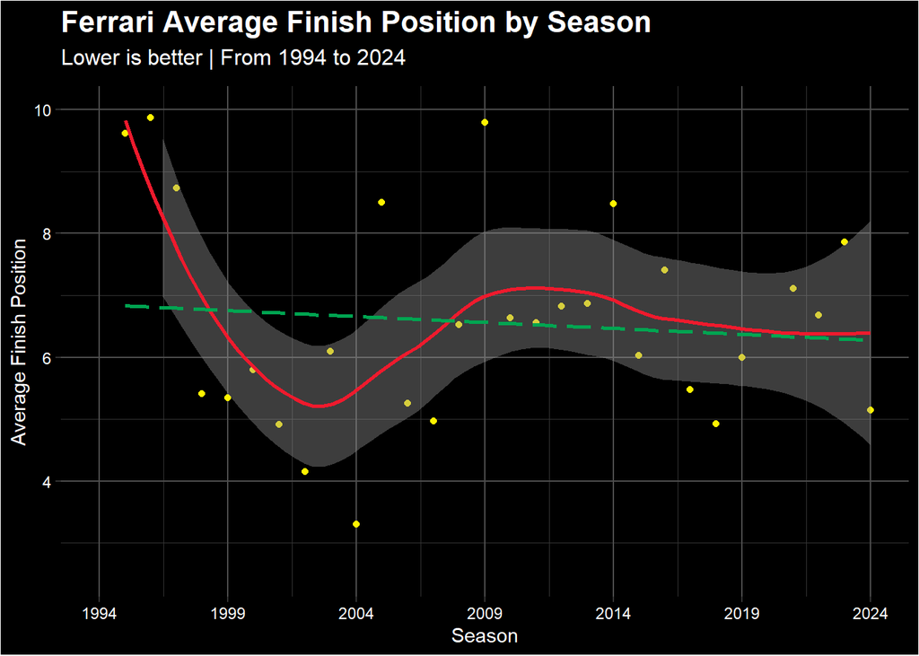

#### Ferrari’s Qualifying Positions

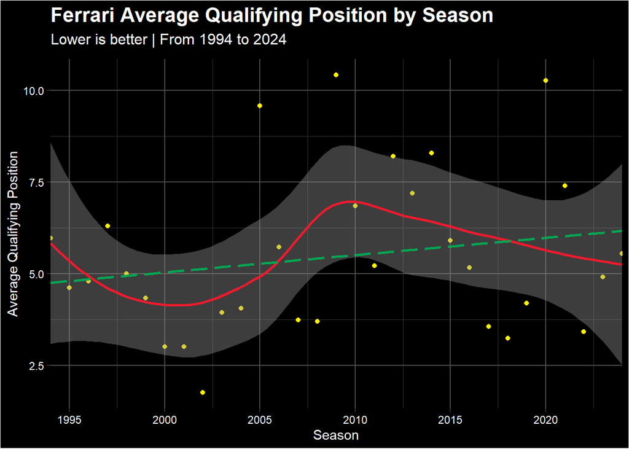

#### Ferrari’s Race Run Time

##### Run time is the amount of time it takes for a driver to complete a particular race.

Our next two graphs are not to show correlations but to show the overall trend over time. First, our average runtime graph refers to the time it takes for Ferrari to complete the entire championship race. The apparent trend is significantly downwards implying Ferrari has gotten faster over time.

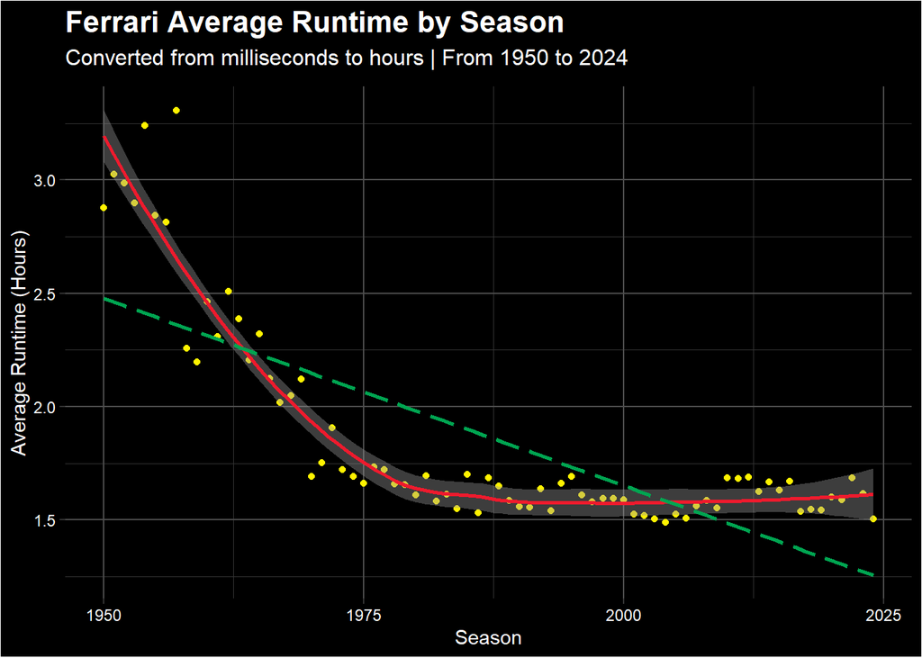

#### Ferrari’s Wins

Finally, we’re left with Ferrari’s wins since 1958. Here, we can see that in 2002 and 2004 Ferrari achieved their all-time high of 15 wins in a season and, on average, are achieving more wins per season.

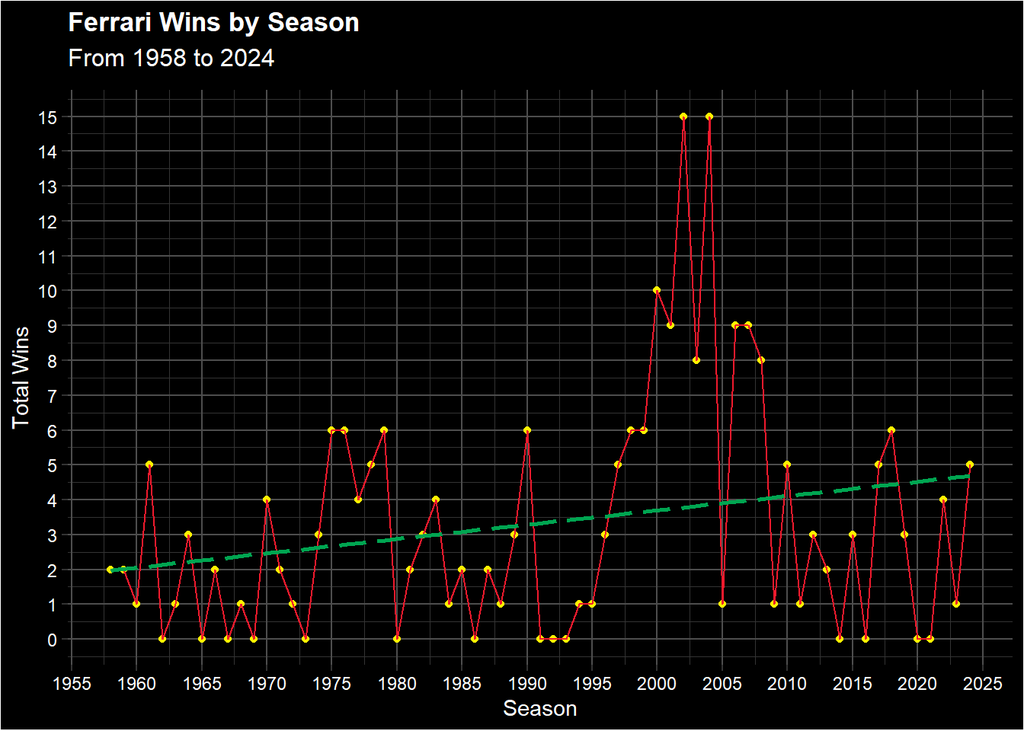

# Our Limitations

While our analysis provides meaningful insight into Ferrari’s performance in Formula 1, there were a few key limitations that shaped our results:

Limited Data Coverage: Some datasets, especially those from earlier years, had missing or inconsistent entries. This made it difficult to carry out long-term analyses across all variables. For instance, data on qualifying times only begins in 1994, and average fastest lap times from 2005, limiting the scope of historical comparisons.

Assumption of Team Uniformity: Our analysis treated Ferrari as a single, consistent team. In reality, performance is influenced by changing drivers, team management, strategies, car designs, and regulation shifts. These nuanced changes weren’t fully reflected in our year-to-year averages.

Simplification Through Averages: We relied on annual averages to reveal broad trends in performance. While effective for spotting general patterns, this method smooths over race-to-race variability and may overlook standout performances or anomalies that could offer deeper insights.

# Conclusion

We specifically explored correlations between qualifying positions and final championship standings, as well as between qualifying times and average fastest lap speeds. These relationships reinforced how critical qualifying performance is to overall success on race day.

However, we also identified a noticeable dip in performance between 2006 and 2013, which aligns with major FIA regulation, and engine type changes aimed at slowing cars down for safety. This highlights how external factors, such as rule changes, can have a major impact, sometimes more than internal team development alone.

Overall, Ferrari’s ability to adapt and continue improving stands out. With the growing role of data science in sports and greater access to detailed performance metrics, there’s strong potential to uncover even deeper, more predictive insights into team performance and trends across F1 as a whole.